# Associations between Diabetes and Obesity: An NHANES Cross-Sectional Study

# Statement of Purpose

In the interest of pursuing programmatic fluency both autodidactically and through the application of class-taught material, the following project was initiated. Diabetes mellitus (DM) was selected as the disease of interest for no particular reason, and obesity (OB) was analyzed as the exposure of interest. Throughout this investigation, the following methods and data collection techniques were implemented: (1) NHANES data collection featuring access to 2,713 medical records from the 2015 to 2016 MEC cycle; (2) stratification by sex, age, education level, and marital status; and (3) logistic regression analysis of DM given the body mass index (BMI) predictor variable, adjusted for age.

# Background

Diabetes mellitus is an endocrine disease that has destructive consequences for cerebrovascular health. There is a growing body of evidence to suggest diabetes as a risk factor for the development of atherosclerosis, and strokes and transient ischemic attacks by extension, as well as microvascular disease, and Alzheimer’s disease and vascular cognitive impairment by extension (Ergul & Fagan, 2017). For these reasons, DM has become one of the biggest threats to human health in recent time (Zimmet, 2001). Known risk factors for DM include overweight and obesity status; age; physical inactivity; maternal diabetes status during gestation; low birth weight; absence of breast-feeding; high-fat diets and diets poor in fiber, fruits, and vegetables; smoking status; and chronic inflammation (Barker & Martyn, 1992; Dabelea et al., 2000; Feskens et al., 1995; Haffner, 1998; Hales et al., 1991; Hu et al., 1999; Knowler et al., 1993; O’Dea, 1992; Ogden et al., 2002; Qiao et al., 2015; Rimm et al., 1993). In 2015-2016 the reference proportions of diabetes and obesity were 13.3% and 29.6%, respectively (Fang, 2018; Lundeen et al., 2018).

# Results & Discussion

Some 2,713 medical records were obtained from the NHANES 2015 to 2016 MEC cycle. The BMX, DEMO, GHB, OGTT, and PFG datasets were used for analysis, from which data regarding BMI, demographic information, glycohemoglobin or A1C test results, oral glucose tolerance test (OGTT) results, and plasma fasting glucose (PFG) test results, correspondingly. Patients were considered DM positive if they tested positive for any one of these three tests. In concordance with the American Diabetes Association, the cutoffs used for DM positive determination are $\geq 6.5$%, $\geq 126$ mg/dL, and $\geq 200$ mg/dL for A1C, PFG, and OGTT, correspondingly. The weights provided by the smallest NHANES dataset were applied to each observation such that the demographic information for each participant was weighted proportionate to the corresponding demographic information of the general U.S. population. To account for confounders, the data was stratified by sex, age, education level, and marital status, then cross-tabulated (Figure 1). The observed prevalences of diabetes and obesity are 11.9% (p=0.04) and 37.3% (p<0.001), respectively. The p-values are relative to the reference proportions 13.3% and 29.6%, respectively. Therefore, the sample used for this study is statistically significantly different from the general U.S. population. This is a notable drawback; MEC-assessed patients are not chosen at random, so the resulting samples, even after applying the recommended demographic weights, cannot be treated as random samples.

The cross-tabulation in Figure 1 suggests that none of the stratified variables are confounders because significant overlap exists for the odds ratio confidence intervals for each subgroup. Obesity is strongly associated with diabetes (2.87, 2.26-3.64). Since age was an expected confounder, logistic regression analysis was performed on diabetes status as the outcome variable, and BMI and age as predictor variables. The five-unit $\beta$-values for BMI and age are 0.377 and 0.260, respectively, with odds ratios 1.46 and 1.30, respectively. This means that the odds of diabetes in patients with a 5-point higher BMI are 1.46 times the odds in patients with some reference BMI level; and similarly, the odds of diabetes in patients with a 5-year age increase are 1.30 times the odds in patients with some reference age.

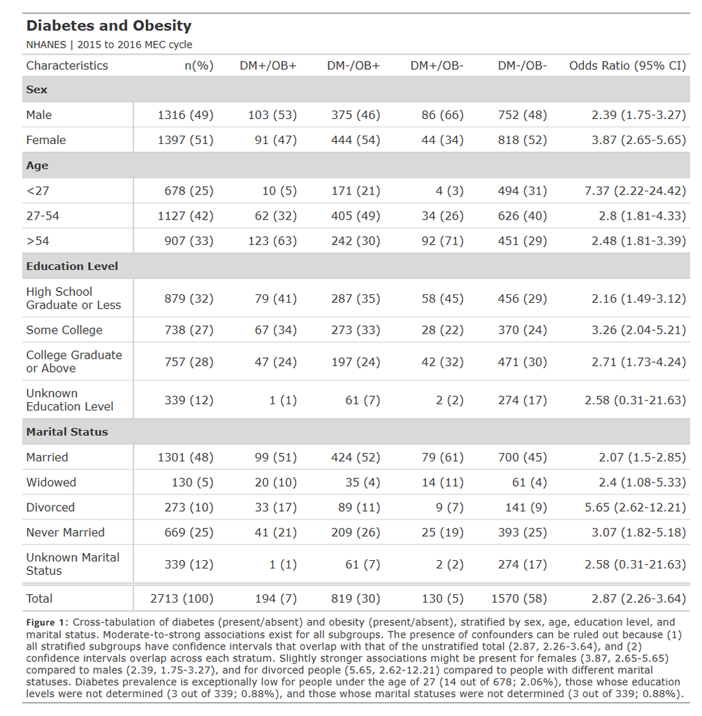